# homework_smirnov_ve_regression2_1

## №2

$x_1 \sim N(\mu_1, \sigma_1^2), \quad x_2 \sim N(\mu_2, \sigma_2^2), \quad x_3 \sim N(\mu_3, \sigma_3^2)$

$$ \text{corr}(x_1, x_2) = 0.0, \quad \text{corr}(x_1, x_3) = 0.0, \quad \text{corr}(x_2, x_3) = 0.8, \quad N = 1000 $$

Сгенерируйте зависимую переменную $y$ по формуле:

$$ y = \beta_0 + \beta_1 x_1 + \beta_2 x_2 + \beta_3 x_3 + \varepsilon $$

где $\varepsilon \sim N(0, \sigma_\varepsilon^2), \quad \beta_i \neq 0$.

### Задача

Проведите процедуру симуляции выборки для данной задачи на 10 тыс. итерациях.  
Итеративно сохраняйте нужные результаты модели и:

1. Проверьте утверждение, что **«Коэффициент модели** $\beta_1$ **примерно в 95% итераций попадает в доверительные интервалы коэффициента** $\hat{\beta}_1$ **при уровне значимости 5%»**.
2. В какой доле итераций коэффициенты модели $\beta_2$ и $\beta_3$ попадают в доверительные интервалы своих оценок при уровне значимости 5%?

```python
# Подключим нужные для базовых операций библиотеки
import seaborn as sb
from matplotlib import pyplot as plt
import numpy as np
import pandas as pd

# Подключим пакеты для использования OLS метода и тестов
import statsmodels.api as sm
from sklearn.linear_model import LinearRegression
from scipy import stats
from statsmodels.stats.outliers_influence import variance_inflation_factor

# Подгрузим полезные функции
from utils import *

# Сделаем автоподгрузку всех изменений при перепрогонке ячейки
%load_ext autoreload
%autoreload 2
```

```python
%reload_ext autoreload
```

### Генерация датасета

```python
# Определим параметры выборки для задачи преобразования факторов
# Создадим удобный словарь, чтобы передавать его в функцию
dist_params = dict(

    # Зададим параметры распределения факторов
    x1_mean = 100.0,
    x1_std = 20.0,
    x2_mean = 30.0,
    x2_std = 6.0,
    x3_mean = 50.0,
    x3_std = 12.0,
    corr_12 = 0.0,
    corr_13 = 0.0,
    corr_23 = 0.8,

    # Зададим параметры распределения ошибки
    e_mean = 0,
    e_std = 100.0,

    # Укажем размер выборки
    N = 1000, # 1к

    # Зададим действительные параметры модели
    beta0 = 50,
    beta1 = 6.7,
    beta2 = 2.3,
    beta3 = 4.1
)

# Установим стартовую точку для алгоритма генерации случайных чисел
RANDOM_SEED = 42
```

```python
# Сгенерируем датасет с нормальным распределением в регрессоре

dt_multivariate = gen_data(y_type='multivariate', params=dist_params, seed=RANDOM_SEED)
display(dt_multivariate)
```

|  | x1 | x2 | x3 | e | y |
| --- | --- | --- | --- | --- | --- |
| 0 | 109.934283 | 28.739223 | 52.504810 | -190.780756 | 877.148876 |
| 1 | 130.460597 | 31.923944 | 52.483417 | -86.038501 | 1126.654580 |
| 2 | 131.584256 | 27.466253 | 40.226501 | -41.360553 | 1118.355001 |
| 3 | 110.851201 | 33.814867 | 54.911883 | 188.768766 | 1284.384724 |
| 4 | 104.839245 | 45.146629 | 70.540822 | 55.655312 | 1201.132873 |
| ... | ... | ... | ... | ... | ... |
| 995 | 80.799074 | 30.349307 | 51.586919 | 2.845758 | 875.509328 |
| 996 | 77.395926 | 12.913990 | 23.239279 | -207.781182 | 485.754740 |
| 997 | 112.042366 | 30.274932 | 48.860443 | -32.029780 | 1038.614234 |
| 998 | 80.961631 | 28.813593 | 49.416429 | 164.337816 | 1025.659364 |
| 999 | 75.164788 | 28.746734 | 45.809134 | 36.064789 | 843.603811 |

1000 rows × 5 columns

```python
# Создаем словарь для хранения коэффициентов и доверительных интервалов
coefficients = {
    'beta1': [], 'beta1_low': [], 'beta1_high': [],
    'beta2': [], 'beta2_low': [], 'beta2_high': [],
    'beta3': [], 'beta3_low': [], 'beta3_high': [],
}

# Перебираем размер выборки от 30 до 1000
for sample_size in range(30, 1001):
    dist_params['N'] = sample_size

    # Генерируем данные и обучаем модель
    data = gen_data(y_type='multivariate', params=dist_params, seed=RANDOM_SEED)
    _, model = train_model(data, target='y', feature_names=['x1', 'x2', 'x3'])

    # Получаем доверительные интервалы
    conf_intervals = model.conf_int()

    # Сохраняем коэффициенты и границы доверительных интервалов
    coefficients['beta1'].append(model.params.iloc[1])
    coefficients['beta1_low'].append(conf_intervals.iloc[1, 0])
    coefficients['beta1_high'].append(conf_intervals.iloc[1, 1])
    coefficients['beta2'].append(model.params.iloc[2])
    coefficients['beta2_low'].append(conf_intervals.iloc[2, 0])
    coefficients['beta2_high'].append(conf_intervals.iloc[2, 1])
    coefficients['beta3'].append(model.params.iloc[3])
    coefficients['beta3_low'].append(conf_intervals.iloc[3, 0])
    coefficients['beta3_high'].append(conf_intervals.iloc[3, 1])
```

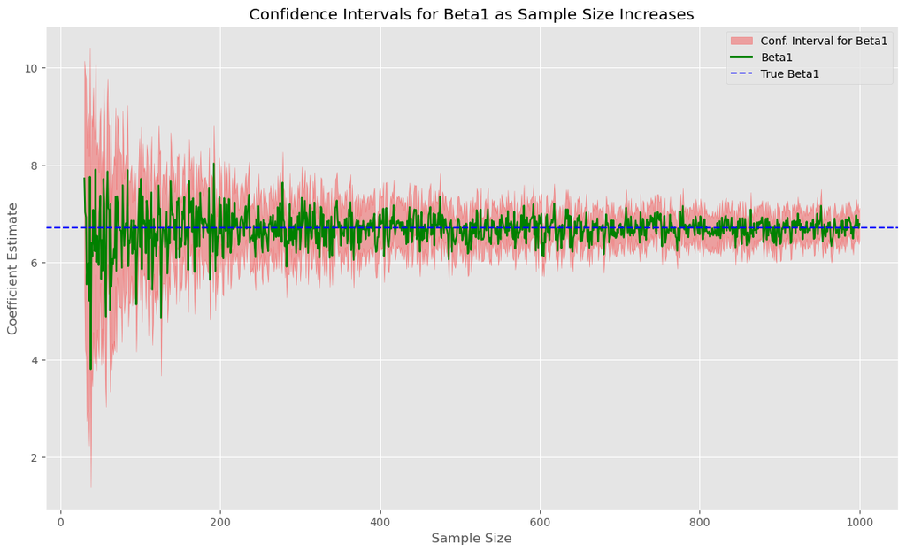

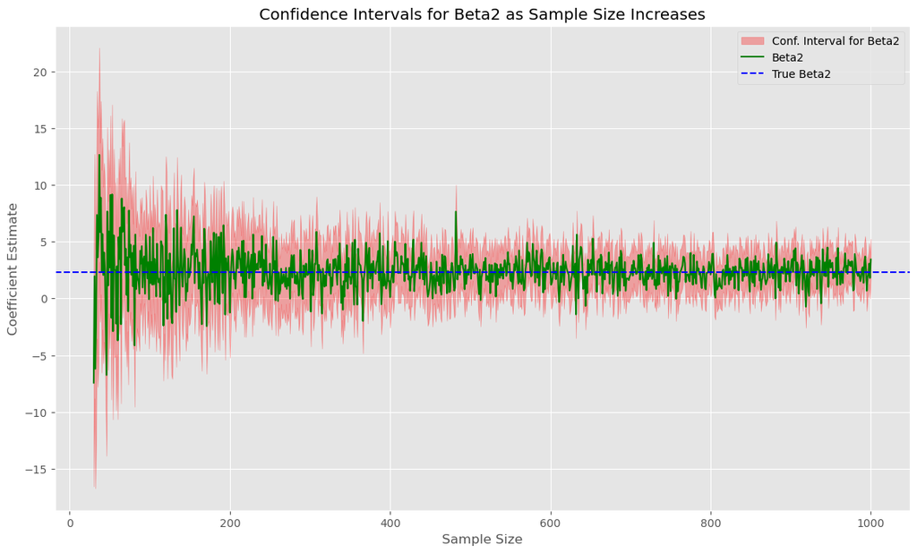

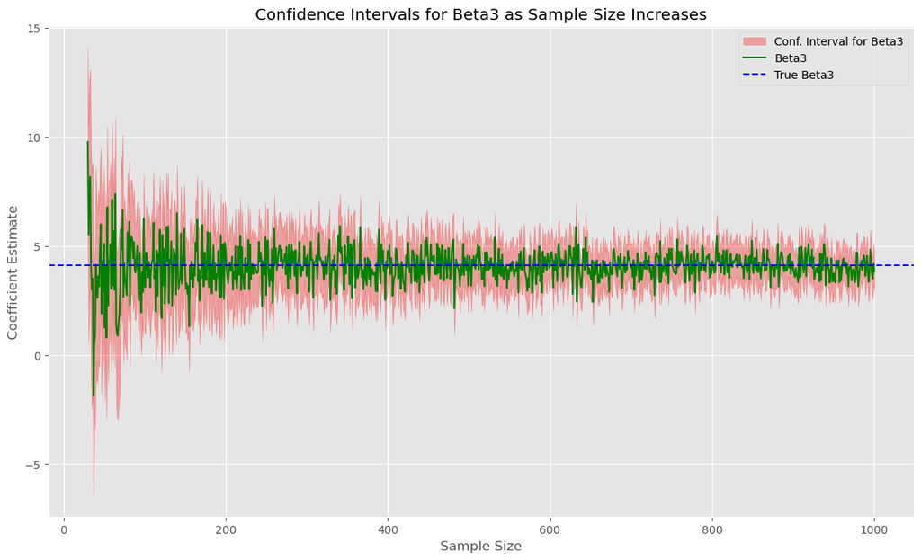

```python
# Визуализация
plt.style.use('ggplot')
plt.figure(figsize=(14, 8))

X = list(range(30, 1001))
plt.fill_between(X, coefficients['beta1_low'], coefficients['beta1_high'], alpha=0.3, label='Conf. Interval for Beta1', color='red')
plt.plot(X, coefficients['beta1'], label='Beta1', color='green')
plt.axhline(dist_params['beta1'], color='blue', linestyle='dashed', label='True Beta1')

plt.xlabel('Sample Size')
plt.ylabel('Coefficient Estimate')
plt.legend()
plt.title('Confidence Intervals for Beta1 as Sample Size Increases')
plt.show()

# Визуализация
plt.style.use('ggplot')
plt.figure(figsize=(14, 8))

X = list(range(30, 1001))
plt.fill_between(X, coefficients['beta2_low'], coefficients['beta2_high'], alpha=0.3, label='Conf. Interval for Beta2', color='red')
plt.plot(X, coefficients['beta2'], label='Beta2', color='green')
plt.axhline(dist_params['beta2'], color='blue', linestyle='dashed', label='True Beta2')

plt.xlabel('Sample Size')
plt.ylabel('Coefficient Estimate')
plt.legend()
plt.title('Confidence Intervals for Beta2 as Sample Size Increases')
plt.show()

# Визуализация
plt.style.use('ggplot')
plt.figure(figsize=(14, 8))

X = list(range(30, 1001))
plt.fill_between(X, coefficients['beta3_low'], coefficients['beta3_high'], alpha=0.3, label='Conf. Interval for Beta3', color='red')
plt.plot(X, coefficients['beta3'], label='Beta3', color='green')
plt.axhline(dist_params['beta3'], color='blue', linestyle='dashed', label='True Beta3')

plt.xlabel('Sample Size')
plt.ylabel('Coefficient Estimate')
plt.legend()
plt.title('Confidence Intervals for Beta3 as Sample Size Increases')
plt.show()
```

### Проверьте утверждение, что «Коэффициент модели примерно в 95% итераций попадает в доверительные интервалы коэффициента при уровне значимости 5%».

#### В какой доле итераций коэффициенты модели и попадают в доверительные интервалы своих оценок при уровне значимости 5%?

```python
# Количество итераций
num_iterations = 10_000

# Словари для хранения результатов
inside_ci_counts = {'beta1': 0, 'beta2': 0, 'beta3': 0}

# Истинные коэффициенты модели
true_betas = {'beta1': dist_params['beta1'],
              'beta2': dist_params['beta2'],
              'beta3': dist_params['beta3']}

for _ in range(num_iterations):
    data = gen_data(y_type='multivariate', params=dist_params, seed=None)
    _, model = train_model(data, target='y', feature_names=['x1', 'x2', 'x3'])

    conf_intervals = model.conf_int()

    # Проверяем попадание истинных значений в доверительные интервалы
    for i, beta in enumerate(['beta1', 'beta2', 'beta3']):
        lower, upper = conf_intervals.iloc[i + 1]
        if lower <= true_betas[beta] <= upper:
            inside_ci_counts[beta] += 1

# Рассчитываем доли попаданий
ci_coverage = {beta: inside_ci_counts[beta] / num_iterations for beta in inside_ci_counts}

print(f"Доля попаданий β1 в доверительный интервал: {ci_coverage['beta1']:.3f}")
print(f"Доля попаданий β2 в доверительный интервал: {ci_coverage['beta2']:.3f}")
print(f"Доля попаданий β3 в доверительный интервал: {ci_coverage['beta3']:.3f}")
```

```
Доля попаданий β1 в доверительный интервал: 0.947
Доля попаданий β2 в доверительный интервал: 0.953
Доля попаданий β3 в доверительный интервал: 0.952
```

### Выводы:

Уже можно было сделать некоторые выводы, обращая внимание лишь на графики (хоть там речь шла про разные размеры выборок, а не сугубо шла речь об итеративно-полученных коэффициентах), но, тем не менее, проверка показала, что оценки в значительном большинстве (**~ 95%**) итераций попадают в свои доверительные интервалы.